# Color Referent Image Inventory

Coverage, acquisition pipeline, and filtering decisions for images

Author

Thomas Brochhagen

Published

March 9, 2026

## Overview

This report documents the image acquisition pipeline. The goal is to obtain visual representations of the unique concepts that, cross-linguistically, appear as sources; to then extract mean saliency maps from these images, and then recast the results as distributions over Munsell chips for comparison with the World Color Survey (WCS). This report is about the first step two steps: finding images to represent the concepts, and extracting saliency maps from them.

I’m also using this to track the pre-processing decisions I took and their potential consequences/biases, since those choices directly affect what color signals end up in the saliency maps.

The pipeline:

| Step | Script | Description |
| --- | --- | --- |
| **1-2** | **`04-fetch-images.py`** | **Download + bbox-crop images from curated datasets** |

## Concept list

```r
library(dplyr)
library(ggplot2)
library(readr)

df_glosses <- read_csv("../data/unique_glosses.csv", show_col_types = FALSE)
cat(sprintf("Unique cleaned glosses: %d\n", length(unique(df_glosses$cleangloss))))
```

```
Unique cleaned glosses: 617
```

Top 20 most frequent sources across languages:

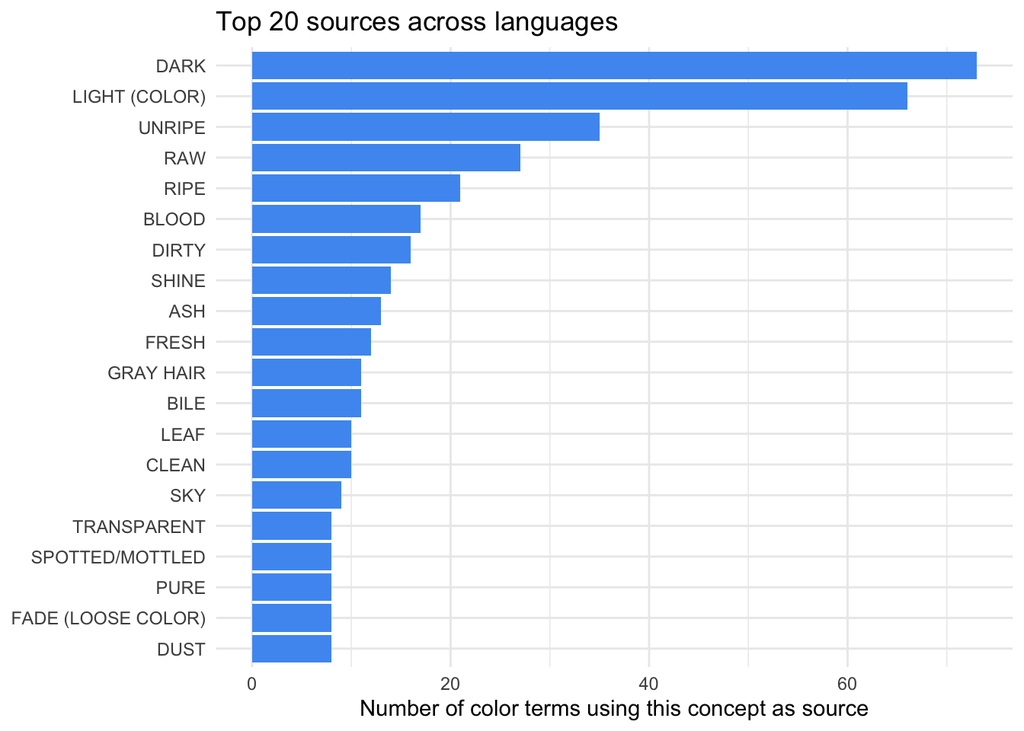

```r
df_cgloss <- read_csv("../data/color-cgloss.csv", show_col_types = FALSE)

df_cgloss |>
  count(source, sort = TRUE) |>
  slice_head(n = 20) |>
  ggplot(aes(x = reorder(source, n), y = n)) +
  geom_col(fill = "#4e9af1") +
  coord_flip() +
  labs(x = NULL, y = "Number of color terms using this concept as source",
       title = "Top 20 sources across languages") +
  theme_minimal()
```

## Image sources

So far, images are drawn from curated, research-grade datasets (e.g., not crawled from WikiMedia). Sources 1–4 use bounding-box annotations (squares that identify the target object in an image) so every saved image is cropped to the annotated object (plus 10% padding), giving concept-centred frames. This may be better suited to saliency analysis. Sources 5–6 lack per-instance bboxes but are already organism- or object-centred by design, so full images are saved after a minimum-size check. I expect these to be a little noisier.

| # | Dataset | License | Image pool | Bbox? | Sources covered |
| --- | --- | --- | --- | --- | --- |
| 1 | **LVIS v1** | CC BY 4.0 | COCO train2017 (~118 k images) | Yes — `[x, y, w, h]` px | 22 |
| 2 | **COCO instances** | CC BY 4.0 | Same pool | Yes — `[x, y, w, h]` px | 3 |
| 3 | **OpenImages V7** | Various CC | ~1.7 M images (CVDF S3) | Yes — `[XMin, XMax, YMin, YMax]` norm. | 12 |
| 4 | **VAW** (Visual Attributes in the Wild) | Research use | Visual Genome (~108 k images, Stanford) | Yes — `[left, top, w, h]` px | 59 |
| 5 | **iNaturalist** | CC0 / CC-BY / CC-BY-SA | API (~180 M observations) | No — full image | 29 (after manual exclusions) |
| 6 | **ImageNet-21k** | Research use | Local download required (~14 M images) | No — full image | TBD (requires local data) |

**Not used for now:**

- *COCO-Stuff*: background categories (sky, grass, snow…) have bboxes that span large scene regions, making cropping uninformative for isolating the concept. I’m not sure about this choice because some of these are used as sources. But I first excluded this data to get a working pipeline with clearer cases off the ground. **[DECISION TO CIRCLE BACK TO]**
- *Wikimedia Commons*: no bbox annotations and highly variable image quality. I tried this and it was messy. I could still source from Wikimedia and then have a human sort through it but then we need clearer guidelines for image selection. **[DECISION TO CIRCLE BACK TO]**

### Source access details

**OpenImages** — images fetched directly from the CVDF public S3 bucket over HTTP (no AWS CLI required): `https://s3.amazonaws.com/open-images-dataset/train/{id}.jpg`. The per-concept annotation index is built once from `oidv6-train-annotations-bbox.csv` and cached as `data/img-data/oi_index.parquet` for fast subsequent runs.

**VAW** — images fetched from Stanford’s public Visual Genome hosting: `https://cs.stanford.edu/people/rak248/VG_100K/{id}.jpg` (with `VG_100K_2` as fallback). For non-commercial research use.

**iNaturalist** — photos fetched on-demand from the iNaturalist API (`https://api.inaturalist.org/v1/observations`) filtered to `photo_license=cc0,cc-by,cc-by-sa` and `quality_grade=research`. The `square` thumbnail URL returned by the API is rewritten to `large` (max 1024 px) before download. API rate limit: ≤1 request/second.

**ImageNet-21k** — requires a local copy of the dataset. Provide the root directory with `--imagenet21k-dir PATH`. Concepts are matched to synsets via `words.txt` (synset_id → comma-separated names bundled with the dataset).

## Filtering decisions and potential biases

This section documents the automated filters applied during image acquisition. These choices should be kept in mind for down-stream analyses.

### F1 — Dataset source filter

**Decision**: six sources are used in priority order: LVIS → COCO-instances → OpenImages V7 → VAW → iNaturalist → ImageNet-21k.

Each source is either openly CC-licensed or available for non-commercial research use and provides either bbox annotations (sources 1–4) or organism/object-centred photographs (sources 5–6).

**Bias**:

- COCO/LVIS/OpenImages were collected with English-language queries and are biased toward Western, anglophone visual culture [@lin2014microsoft; @gupta2019lvis].
- VAW (Visual Genome) shares the same English-centric Flickr image pool.
- iNaturalist is biased toward North American and European biodiversity hotspots where the app has the most users; tropical and Southern-hemisphere taxa are under-represented.
- ImageNet-21k was sourced from web image search and inherits similar cultural biases.
- Concepts from non-Western or non-commercial contexts (*egbo powder*, *dawa dawa fruit*, *boiled taraγ*) have close to zero coverage across all sources.

### F2 — Minimum crop size: 150 × 150 px (for images with bounding boxes)

**Decision**: crops smaller than 150 × 150 pixels after padding are discarded. Very small crops are too low-resolution for reliable saliency computation.

**Bias?**

- Maybe excludes distant or small instances of objects; which is to say that it favors large, prominent referents. Not sure if this is an issue but worth keeping in mind.

### F3 — Maximum crop-to-image ratio: 0.75 (for images with bounding boxes)

**Decision**: crops whose area exceeds 75% of the original image area are discarded. When the bounding box fills nearly the entire image the annotation often corresponds to a studio/product shot, taxidermied specimen, toy, or carved replica rather than a natural in-situ instance. These would contribute incorrect color signals (e.g., a wooden deer carving is the wrong color for “deer”).

**Bias?**

- May exclude close-up macro photography of naturally photogenic objects (insects, flowers, coins) that genuinely fill the frame.
- Slightly favours mid-range distances where the object is prominent but surrounded by natural context.

### F4 — Sort by descending bbox area (COCO / LVIS)

**Decision**: within a category, annotations are sorted largest-bbox-first; the first *N* distinct images are selected. Larger annotated objects tend to be the intended focus of the image and yield higher-resolution crops.

**Bias?**

- May preferentially sample prominent foreground instances and under-represent the same object at varied sizes or distances.

### F5 — OpenImages quality flags

**Decision**: annotations are sorted by the number of quality flags set to 0 (best quality first): `IsOccluded`, `IsTruncated`, `IsGroupOf`, `IsDepiction`. That is, we prefer non-occluded, non-truncated, individually-annotated, photographic instances to provide the most unambiguous color signal.

**Potential biases** (though I think these are very clear cut):

- `IsGroupOf = 0`: prefers individual instances over groups/crowds; may under-represent objects that are typically seen in aggregates (coins in a pile, grapes in a bunch, etc.).
- `IsDepiction = 0`: prefers photographs over paintings, logos, or illustrations. For concepts like *rose*, this means predominantly photographic roses rather than stylised representations. Note: this flag does **not** catch all depictions; see manual curation entry #1 (*honeycomb*) where an image of a printed book cover passed this filter.
- `IsOccluded = 0 / IsTruncated = 0`: prefers fully visible objects; may under-represent naturally partial views (e.g., a deer partly behind a tree).

### F6 — Bounding-box padding: 10%

**Decision**: each crop is expanded by 10% of the bbox dimensions on each side before saving. Saliency models benefit from a small amount of surrounding context for edge detection and figure-ground separation. Without any padding, a tightly clipped object would look unnatural to the model.

**Bias?** This Introduces some background context into each crop, which may attract saliency away from the referent itself. The 10% value is a relatively arbitrary choice; larger padding reintroduces more background noise. I don’t expect the difference between a few percentage points to matter but I haven’t tested. Not even sure if this does much but I’ve seen this choice in some papers.

### F7 — Exact / near-exact string matching for category lookup

**Decision**: concept glosses are matched to dataset categories by exact lowercase string matching, plus underscore-normalisation and synonym lookup for LVIS. iNaturalist additionally performs server-side taxon-name search (scientific and common names), which provides some implicit synonym coverage for biological taxa.

I imagine that fuzzy matching would risk cross-category contamination (e.g., matching “lime” to “lemon”). We may want to do this for some sources though… so **[DECISION TO CIRCLE BACK TO]**

### F8 — iNaturalist: research-grade filter

**Decision**: only observations with `quality_grade=research` are used. iNaturalist assigns “research grade” when ≥2/3 of community identifications agree on a taxon. This ensures the taxon label is reliable.

**Consequence**:

- Preferentially retains common, easily-identified taxa in well-surveyed regions. Rare or visually ambiguous species are under-represented because they rarely achieve research grade.
- Also, note that iNaturalist photos are taken by citizen scientists in the field, so they tend to show organisms in natural habitat. This is good for our purposes. However, photo quality varies more than in professionally curated datasets. I saw that a few images of boars are in black and white. So maybe that should be checked for. **[DECISION TO CIRCLE BACK TO, at least to exclude black and white]**

### F9 — iNaturalist: open photo license filter

**Decision**: only photos with `photo_license` ∈ {`cc0`, `cc-by`, `cc-by-sa`} are downloaded.

**Rationale**: these licenses permit academic redistribution and reuse.

### Summary table

```r
tribble(
  ~Filter, ~Parameter, ~Effect, ~Bias_direction,
  "F1 — Dataset source",      "LVIS > COCO > OI > VAW > iNat > IN21k",  "Six curated sources in priority order", "Western/anglophone bias; iNat skewed to N. America/Europe",
  "F2 — Min crop size",       "150 × 150 px",           "Discard tiny crops",               "Favours large, prominent instances",
  "F3 — Max crop fraction",   "≤ 75% of image area",    "Discard whole-scene bbox",         "Excludes studio shots & replicas; may exclude macro photography",
  "F4 — Sort by bbox area",   "Largest first",          "Select prominent instances",       "Favours foreground, large specimens",
  "F5 — OI quality flags",    "Prefer 0 on all flags",  "Prefer unoccluded photos",         "Prefers isolated, photographic, individual instances",
  "F6 — Bbox padding",        "10%",                    "Add context around object",        "Adds background; affects saliency model boundary detection",
  "F7 — String matching",     "Exact + synonyms",       "Determine which concepts get images", "Zero coverage for most concepts (culturally specific, abstract)",
  "F8 — iNat quality grade",  "research only",          "Community-verified IDs only",      "Favours common, easily-ID'd taxa in well-surveyed regions",
  "F9 — iNat photo license",  "cc0 / cc-by / cc-by-sa","Open-license photos only",         "--",
  "M1 — Manual rejection",    "manual: in rejected.txt","Exclude images failing visual inspection", "Subjective; depends on curator judgement",
  "M2 — no_fetch sentinel",   "touch no_fetch",         "Disable automated search; manual sourcing only", "Manual images bypass automated quality filters",
) |>
  knitr::kable(
    col.names = c("Filter", "Parameter", "Effect", "Bias direction"),
    caption = "Automated filtering decisions and their bias implications"
  )
```

Automated filtering decisions and their bias implications

| Filter | Parameter | Effect | Bias direction |
| --- | --- | --- | --- |
| F1 — Dataset source | LVIS > COCO > OI > VAW > iNat > IN21k | Six curated sources in priority order | Western/anglophone bias; iNat skewed to N. America/Europe |
| F2 — Min crop size | 150 × 150 px | Discard tiny crops | Favours large, prominent instances |
| F3 — Max crop fraction | ≤ 75% of image area | Discard whole-scene bbox | Excludes studio shots & replicas; may exclude macro photography |
| F4 — Sort by bbox area | Largest first | Select prominent instances | Favours foreground, large specimens |
| F5 — OI quality flags | Prefer 0 on all flags | Prefer unoccluded photos | Prefers isolated, photographic, individual instances |
| F6 — Bbox padding | 10% | Add context around object | Adds background; affects saliency model boundary detection |
| F7 — String matching | Exact + synonyms | Determine which concepts get images | Zero coverage for most concepts (culturally specific, abstract) |
| F8 — iNat quality grade | research only | Community-verified IDs only | Favours common, easily-ID’d taxa in well-surveyed regions |
| F9 — iNat photo license | cc0 / cc-by / cc-by-sa | Open-license photos only | – |
| M1 — Manual rejection | manual: in rejected.txt | Exclude images failing visual inspection | Subjective; depends on curator judgement |
| M2 — no_fetch sentinel | touch no_fetch | Disable automated search; manual sourcing only | Manual images bypass automated quality filters |

## Coverage results

```r
manifest_path <- "../data/images/manifest.csv"

if (file.exists(manifest_path)) {
  manifest <- read_csv(manifest_path, show_col_types = FALSE)
  total   <- nrow(manifest)
  any_img <- sum(manifest$n_images > 0)
  zero    <- sum(manifest$n_images == 0)
  full    <- sum(manifest$n_images >= 20)

  cat(sprintf("Concepts processed:              %d\n", total))
  cat(sprintf("  ≥ 1 image:                     %d (%.0f%%)\n", any_img, 100 * any_img / total))
  cat(sprintf("  ≥ 20 images:                   %d (%.0f%%)\n", full,    100 * full    / total))
  cat(sprintf("  0 images (no curated match):   %d (%.0f%%)\n", zero,    100 * zero    / total))
} else {
  cat("Manifest not yet available — fetch still running.\n")
}
```

```
Concepts processed:              617
  ≥ 1 image:                     94 (15%)
  ≥ 20 images:                   1 (0%)
  0 images (no curated match):   523 (85%)
```

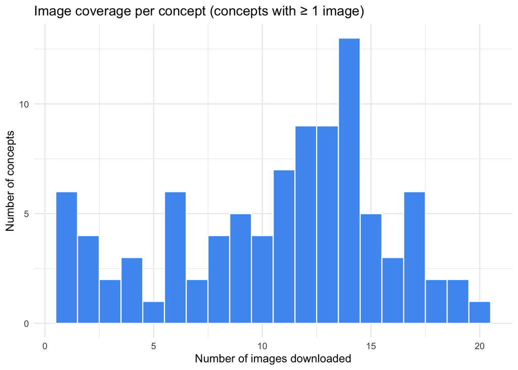

Distribution of image counts per concept (curated sources only)

```r
if (file.exists(manifest_path)) {
  manifest |>
    filter(n_images > 0) |>
    ggplot(aes(x = n_images)) +
    geom_histogram(binwidth = 1, fill = "#4e9af1", color = "white") +
    labs(x = "Number of images downloaded", y = "Number of concepts",
         title = "Image coverage per concept (concepts with ≥ 1 image)") +
    theme_minimal()
}
```

### Concepts with at least one image

Some columns explained further below.

```r
if (file.exists(manifest_path)) {
  manifest |>
    filter(n_images > 0) |>
    arrange(desc(n_images)) |>
    knitr::kable(caption = "Concepts with at least one image")
}
```

Concepts with at least one image

| concept | slug | n_images | no_fetch | final_tv | min_tv |
| --- | --- | --- | --- | --- | --- |
| pompano | pompano | 20 | FALSE | 0.0445445 | 0.0398901 |
| fruit | fruit | 19 | FALSE | 0.0329700 | 0.0329700 |
| roseate spoonbill | roseate_spoonbill | 19 | FALSE | 0.0270927 | 0.0250526 |
| brown booby | brown_booby | 18 | FALSE | 0.0370356 | 0.0308840 |
| bluebird | bluebird | 18 | FALSE | 0.0263409 | 0.0158851 |
| light | light | 17 | FALSE | 0.0428429 | 0.0310679 |
| sky | sky | 17 | FALSE | 0.0357021 | 0.0357021 |
| coin | coin | 17 | FALSE | 0.0278074 | 0.0278074 |
| rose | rose | 17 | FALSE | 0.0330914 | 0.0330914 |
| rosé | rose | 17 | FALSE | 0.0330914 | 0.0330914 |
| cloud | cloud | 17 | FALSE | 0.0296830 | 0.0296830 |
| grass | grass | 16 | FALSE | 0.0359597 | 0.0278085 |
| dirt | dirt | 16 | FALSE | 0.0320975 | 0.0320975 |
| path | path | 16 | FALSE | 0.0270346 | 0.0270346 |
| smoke | smoke | 15 | FALSE | 0.0424306 | 0.0301248 |
| banana | banana | 15 | FALSE | 0.0365009 | 0.0365009 |
| orange | orange | 15 | FALSE | 0.0350618 | 0.0322912 |
| fur | fur | 15 | FALSE | 0.0311205 | 0.0298142 |
| spread | spread | 15 | FALSE | 0.0302635 | 0.0302635 |
| leaf | leaf | 14 | FALSE | 0.0326004 | 0.0326004 |
| lemon | lemon | 14 | FALSE | 0.0430063 | 0.0425670 |
| black rockfish | black_rockfish | 14 | FALSE | 0.0429239 | 0.0314451 |
| vegetable | vegetable | 14 | FALSE | 0.0496000 | 0.0385756 |
| cloth | cloth | 14 | FALSE | 0.0420769 | 0.0400181 |
| masked booby | masked_booby | 14 | FALSE | 0.0290536 | 0.0290536 |
| crown | crown | 14 | FALSE | 0.0377008 | 0.0377008 |
| shadow | shadow | 14 | FALSE | 0.0236134 | 0.0236134 |
| plant | plant | 14 | FALSE | 0.0369698 | 0.0242528 |
| sago palm | sago_palm | 14 | FALSE | 0.0207334 | 0.0207334 |
| lettuce | lettuce | 14 | FALSE | 0.0380018 | 0.0366631 |

[output cut: 64 more lines]

### Zero-coverage concepts (sample)

```r
if (file.exists(manifest_path)) {
  manifest |>
    filter(n_images == 0) |>
    slice_head(n = 30) |>
    pull(concept) |>
    paste(collapse = ", ") |>
    cat()
}
```

```
night, raw, fresh, dirty, beautiful, unripe, dead, tender, red clay, clean, itch, threshing-floor, apple bladder-nut, birthmark, healthy, cassumunar ginger, golden, price, bright, silver, friday, morning star, lucifer, vitiligo, leucorrhoea, dark, blue feather of great cuckoo dove, ash, turmeric, so…
```

## Additional image quality filter (VLM)

After each image is saved to disk, a local vision-language model (VLM) checks whether it meets quality requirements before being counted toward the acquisition target.

This is done only for images that have a Concepticon ID/definition. I did this because otherwise the prompt was at times awkward (e.g., for the concept “bright” it’s not sensible to ask “Is this a color photograph of a real {bright}”).

### Model and platform

**Model**: `mlx-community/Qwen2-VL-2B-Instruct-4bit` (Qwen2-VL 2-billion-parameter multimodal model, 4-bit quantised). **Platform**: Apple Silicon (MLX framework), loaded once per script session. **Speed**: approximately 1–2 seconds per image on Apple M3.

### Prompt

The following prompt is sent for each image:

> *“This image was retrieved for the concept ‘{concept}’. Definition: {definition}. Is this a color photograph of a real {concept} — not black-and-white, not a toy, not taxidermy, not a drawing or illustration? Answer YES or NO, then one sentence of explanation.”*

**Accept criterion**: the response starts with `YES` (case-insensitive). Definitions are sourced from `concepticon-cldf/cldf/concepticon.csv` (the `Description` field), matched to concepts by lower-casing the Concepticon `Name`.

Rejected images are deleted from disk and logged with the prefix `auto:` in `data/images/<slug>/rejected.txt`. They are excluded from all downstream counts and analyses.

**Note**: in practice the model often responds with just `NO` or `YES` without the requested explanation sentence. The accept/reject decision is unaffected, but rejection reasons shown in the curation contact sheets may be uninformative. Apparently we’re not in the AGI era yet :)

## Convergence-based acquisition

Rather than collecting a fixed number of images per concept, script 04 uses a data-driven stopping rule: it stops fetching images once the aggregate saliency-weighted colour distribution has stabilised.

### Convergence metric

After each accepted image, GBVS saliency is computed (same algorithm as script 06, channels `D`, 256 × 256 px) and projected onto the 330 WCS Munsell chips via the row-anchored two-step assignment (Kay & Regier 2003, documented in `reports/munsell-report.qmd`). The running mean distribution $D_k$ (averaged over the first $k$ accepted images) is updated, and the Total Variation (TV) distance from the previous step is recorded:

$$TV(D_k,\, D_{k-1}) \;=\; \tfrac{1}{2}\sum_{i=1}^{330} \lvert D_k[i] - D_{k-1}[i] \rvert$$

TV ranges from 0 (identical distributions) to 1 (completely disjoint distributions). A value of 0.05 means that the aggregate distribution changed by at most 5 percentage points in total mass when one more image was added.

### Stopping rule (current defaults)

| Parameter | Default | Meaning |
| --- | --- | --- |
| `--min-images` | 5 | Minimum valid images before the TV check activates |
| `--tv-eps` | 0.05 | TV threshold |
| `--tv-window` | 3 | Consecutive steps below threshold required to stop |

Acquisition stops for a concept once $TV(D_k, D_{k-1}) < 0.05$ for three consecutive images, with at least 5 valid images already collected. `--n-images` acts as an upper cap (not a fixed target).

The convergence state (TV history, number of valid/rejected images, convergence flag) is saved to `data/images/<slug>/convergence.json` after each concept. On re-runs, already-converged concepts are skipped unless `--force` is passed.

### Distribution reliability (final TV distance)

The convergence check in script 04 records the full TV-distance history for each concept. Two derived quantities in `manifest.csv` summarise reliability:

- **`final_tv`**: TV distance at the last image collected. Converged concepts have `final_tv ≤ 0.05` (the stopping threshold); concepts that hit the 20-image cap may have higher values.
- **`min_tv`**: lowest TV distance ever reached. Useful for cap-limited concepts — a low `min_tv` means the distribution nearly stabilised even if the stopping criterion was not formally met.

Script 07 accepts `--max-tv` to exclude high-`final_tv` concepts from the aggregate comparison plot.

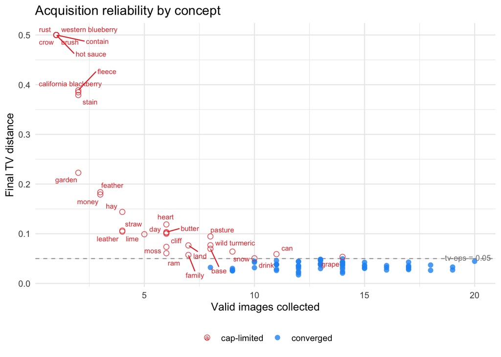

Distribution reliability: final TV distance vs. number of valid images. Converged concepts (filled) always have final_tv ≤ 0.05. Cap-limited non-converged concepts (open) may be noisy (high final_tv) or near-convergence (low final_tv).

```r
if (file.exists(manifest_path) && "final_tv" %in% names(manifest)) {
  library(ggrepel)

  rel <- manifest |>
    filter(n_images > 0, !is.na(final_tv)) |>
    mutate(status = case_when(
      no_fetch ~ "no_fetch",
      final_tv <= 0.05 ~ "converged",
      TRUE ~ "cap-limited"
    ))

  ggplot(rel, aes(x = n_images, y = final_tv, colour = status, shape = status)) +
    geom_hline(yintercept = 0.05, linetype = "dashed", colour = "grey60", linewidth = 0.4) +
    geom_point(size = 2.2, alpha = 0.8) +
    geom_text_repel(
      data = filter(rel, final_tv > 0.05),
      aes(label = concept), size = 2.5, max.overlaps = 15
    ) +
    scale_colour_manual(values = c("converged" = "#2196F3",
                                   "cap-limited" = "#E53935",
                                   "no_fetch" = "#9E9E9E")) +
    scale_shape_manual(values  = c("converged" = 16,
                                   "cap-limited" = 1,
                                   "no_fetch" = 4)) +
    annotate("text", x = Inf, y = 0.052, label = "tv-eps = 0.05",
             hjust = 1.1, size = 2.8, colour = "grey50") +
    labs(x = "Valid images collected", y = "Final TV distance",
         colour = NULL, shape = NULL,
         title = "Acquisition reliability by concept") +
    theme_minimal() +
    theme(legend.position = "bottom")
} else {
  cat("final_tv not yet available — re-run script 04 to populate manifest.csv.\n")
}
```

```r
if (file.exists(manifest_path) && "final_tv" %in% names(manifest)) {
  manifest |>
    filter(n_images > 0, !is.na(final_tv), final_tv > 0.05) |>
    arrange(final_tv) |>
    select(concept, n_images, final_tv, min_tv) |>
    mutate(across(c(final_tv, min_tv), \(x) round(x, 3))) |>
    knitr::kable(col.names = c("Concept", "N images", "Final TV", "Min TV"))
}
```

| Concept | N images | Final TV | Min TV |
| --- | --- | --- | --- |
| drink | 10 | 0.051 | 0.051 |
| grape | 14 | 0.053 | 0.053 |
| family | 7 | 0.057 | 0.057 |
| can | 11 | 0.059 | 0.053 |
| ram | 6 | 0.061 | 0.061 |
| snow | 9 | 0.064 | 0.063 |
| base | 8 | 0.070 | 0.070 |
| moss | 6 | 0.074 | 0.069 |
| land | 7 | 0.077 | 0.071 |
| wild turmeric | 8 | 0.077 | 0.077 |
| pasture | 8 | 0.095 | 0.089 |
| lime | 5 | 0.099 | 0.099 |
| cliff | 6 | 0.100 | 0.083 |
| day | 6 | 0.102 | 0.102 |
| butter | 6 | 0.103 | 0.103 |
| leather | 4 | 0.104 | 0.104 |
| straw | 4 | 0.106 | 0.106 |
| heart | 6 | 0.119 | 0.119 |
| hay | 4 | 0.144 | 0.144 |
| money | 3 | 0.179 | 0.179 |
| feather | 3 | 0.184 | 0.184 |
| garden | 2 | 0.223 | 0.223 |
| stain | 2 | 0.379 | 0.379 |
| california blackberry | 2 | 0.385 | 0.385 |
| fleece | 2 | 0.389 | 0.389 |
| crow | 1 | 0.500 | 0.500 |
| hot sauce | 1 | 0.500 | 0.500 |
| rust | 1 | 0.500 | 0.500 |
| brush | 1 | 0.500 | 0.500 |
| contain | 1 | 0.500 | 0.500 |
| western blueberry | 1 | 0.500 | 0.500 |

### Reminders to myself

At the end of each concept, script 04 saves the final running-mean Munsell distribution to `data/images/<slug>/munsell_distribution.npy`. Script 06 detects this file and loads it directly, skipping GBVS entirely. The distribution computed inline during acquisition is the one used for all downstream analysis — there is no separate authoritative recomputation step.

If the GBVS channel setting (`--channels`) changes, existing `convergence.json` and `munsell_distribution.npy` files become stale. Delete the relevant `data/images/<slug>/` files and re-run script 04 to recompute.

**[CIRCLE BACK TO]** A concept whose early images happen to cover the full colour range well may trigger the stopping rule prematurely. Inspect TV history curves in `convergence.json` for pilot concepts to calibrate whether the threshold and window are appropriate.

## Manual curation

Even after VLM filtering, some images may be unsuitable (e.g., images that passed the VLM check but are judged incorrect on visual inspection). Post-hoc manual curation is supported without re-running the full acquisition pipeline.

### Workflow

1. **Generate contact sheets** for the concepts you want to review:

   ```bash
   conda run -n color python scripts/09-curate.py --only banana,rose
   ```

   This creates `reports/curation/<slug>.html` — a standalone HTML file with all images for that concept, showing filenames, sources, and VLM verdicts.
2. **Review** the HTML in a browser.
3. **Reject images** by adding lines to `data/images/<slug>/rejected.txt`:

   ```
   manual:img_0012.jpg
   manual:img_0017.jpg
   ```

4. **Resume acquisition**: re-run script 04. It reads `rejected.txt`, subtracts manually rejected images from the valid count, and downloads replacements if the concept has not yet re-converged.

### `rejected.txt` schema

```
# auto-rejected by VLM
auto:img_0003.jpg:not a real banana, appears to be plastic
auto:img_0007.jpg:black and white photograph
# manually rejected
manual:img_0012.jpg
```

Lines starting with `auto:` are written by the VLM filter; lines starting with `manual:` are written by hand. Comment lines (starting with `#`) and blank lines are ignored.

### M2 — Disabling automated search (`no_fetch`)

**Decision**: for concepts where automated search consistently returns unusable images, a sentinel file `data/images/<slug>/no_fetch` can be created to suppress all further fetching for that concept. Images for these concepts are sourced manually and placed directly in the concept directory.

Some concepts are not retrievable from the six automated sources in any useful form. Running the full fetch pipeline repeatedly and rejecting all results wastes time and adds noise to the acquisition log. Flagging them explicitly documents the decision rather than leaving them as silent zero-coverage entries.

**How to flag**: `touch data/images/<slug>/no_fetch` during curation review. Re-running script 04 skips all downloading for flagged concepts but still counts any valid images already present. Pass `--force` to override.

**Bias**: manually sourced images bypass the automated quality filters (VLM, minimum crop size, max crop fraction, source priority order). They should be curated with the same criteria in mind. The `no_fetch` column in `manifest.csv` flags these concepts so they can be treated separately in downstream analyses if needed.

```r
if (file.exists(manifest_path) && "no_fetch" %in% names(manifest)) {
  nf <- manifest |> filter(no_fetch)
  if (nrow(nf) > 0) {
    cat(sprintf("%d concept(s) flagged no_fetch:\n", nrow(nf)))
    cat(paste(nf$concept, collapse = ", "), "\n")
  } else {
    cat("No concepts currently flagged no_fetch.\n")
  }
}
```

```
6 concept(s) flagged no_fetch:
turmeric, side, white, reflection, surface, paint
```

## Image examples

**Rose (OpenImages)**

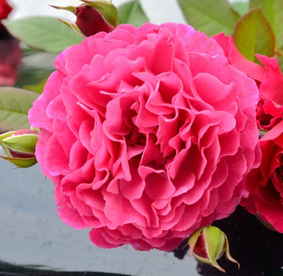

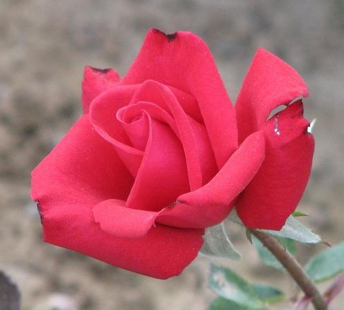

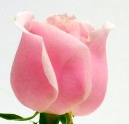

```r
imgs <- list.files("../data/images/rose", "img_.*\\.jpg", full.names = TRUE)
if (length(imgs) > 0) knitr::include_graphics(imgs[1:min(3, length(imgs))])
```

**Monkey (LVIS)**

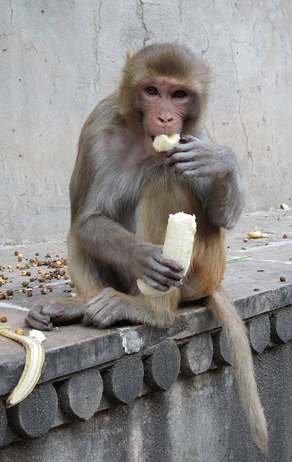

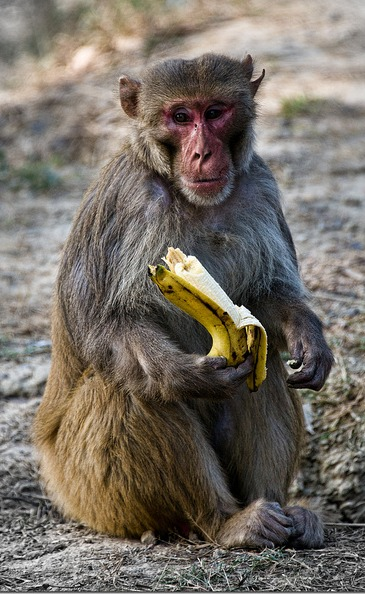

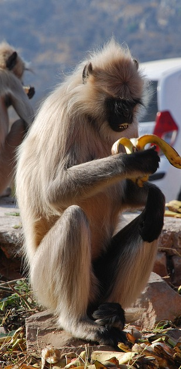

```r
imgs <- list.files("../data/images/monkey", "img_.*\\.jpg", full.names = TRUE)
if (length(imgs) > 0) knitr::include_graphics(imgs[1:min(3, length(imgs))])
```

**Banana (COCO + LVIS)**

[figure not shown]

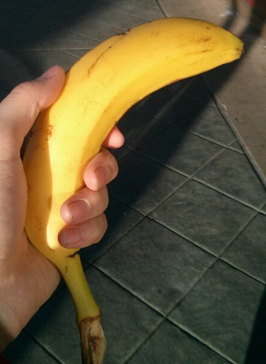

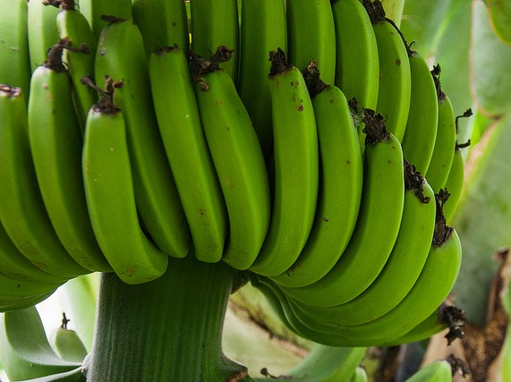

```r
imgs <- list.files("../data/images/banana", "img_.*\\.jpg", full.names = TRUE)
if (length(imgs) > 0) knitr::include_graphics(imgs[1:min(3, length(imgs))])
```

**Lettuce (VAW)**

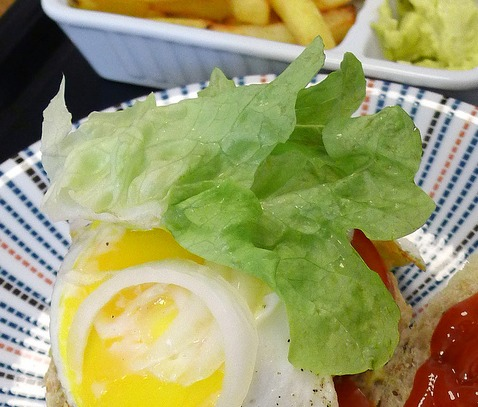

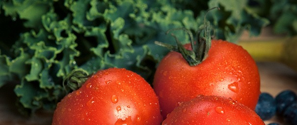

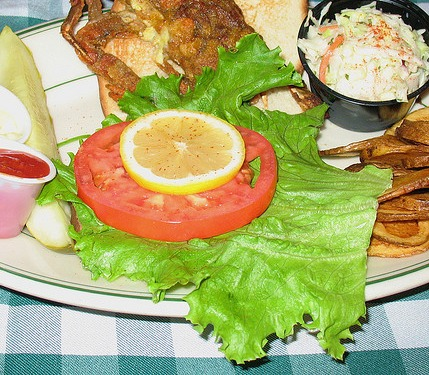

```r
imgs <- list.files("../data/images/lettuce", "img_.*\\.jpg", full.names = TRUE)
if (length(imgs) > 0) knitr::include_graphics(imgs[1:min(3, length(imgs))])
```

**Deer (LVIS + OpenImages)**

*Note: includes a minority of non-living instances (taxidermy, mounted trophies) due to annotation noise in the source dataset — see F3 above.*

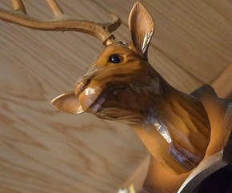

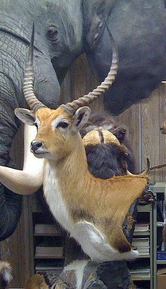

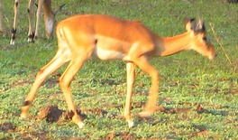

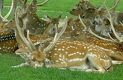

```r
imgs <- list.files("../data/images/deer", "img_.*\\.jpg", full.names = TRUE)
if (length(imgs) > 0) knitr::include_graphics(imgs[1:min(4, length(imgs))])
```

## Manual curation log

The following decisions were made by hand after looking at some downloaded images.

[output not shown]

This log should be updated whenever images are manually reviewed and modified.

## Next steps

### Extending coverage

Some options to extend coverage:

1. **ImageNet-21k local data** — with a local copy of the dataset, I expect coverage would expand at least for everyday objects and many biological taxa. Download from `image-net.org` (registration required) or the Hugging Face mirror; provide the root directory with `--imagenet21k-dir PATH`.
2. **Relax string matching** — use WordNet synonyms, Concepticon concept mappings, or embedding-based fuzzy matching to link more glosses to dataset categories. Risk: higher false-positive rate.
3. **OpenImages V7 extended** — the boxable set covers ~600 categories; there may be additional matches with alternate spellings or synonym lookup.
4. **Manual curation** — for culturally specific items (*egbo powder*, *boiled taraγ*), a small hand-collected set is likely more reliable than any automated pipeline.